# Formal Exploratory Analysis

Anand Rajan

4/16/2022

```r
library(tidyverse)
library(nlme)
library(lme4)
library(haven)
```

## Data Cleaning

# Exploratory

To start, we will be looking out our outcome variable cognition. We can evaluate cognition through three different variables. We have composite cognition z scores, then cognition z scores for episodic memory and executive functioning. We will look at the distributions of all three outcome variables to potentially inform us of what sort of analysese we can run. Moreover we will look at univariate statistics for each of the cognition scores.

```r
shapiro.test(midus$composite_cognition)
```

```
##
##  Shapiro-Wilk normality test
##
## data:  midus$composite_cognition
## W = 0.99823, p-value = 0.3093
```

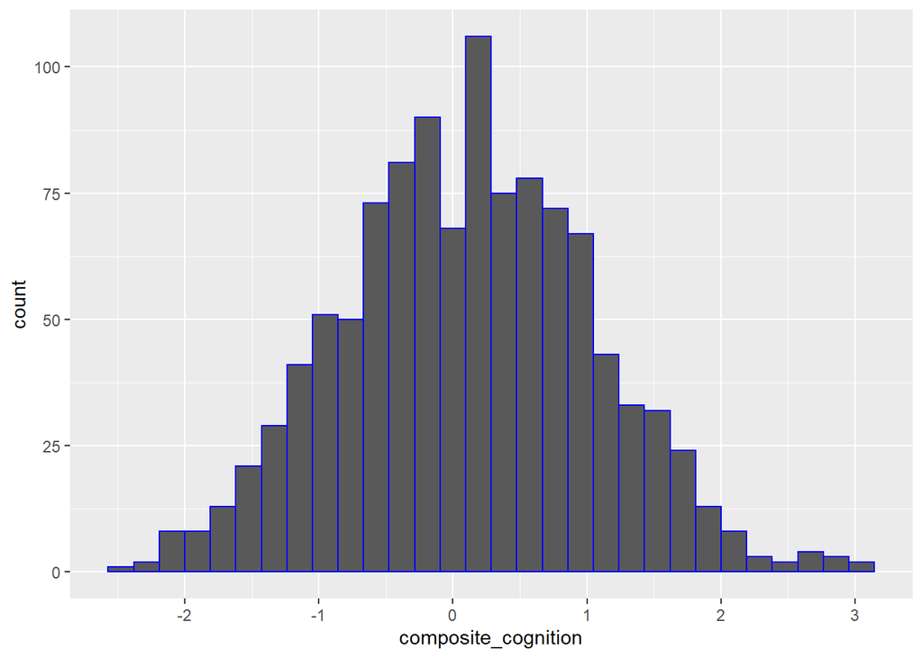

```r
cognition_distribution <- ggplot(midus,aes(x=composite_cognition)) +
                      geom_histogram(color = "blue")

cognition_distribution
```

The histogram indicates a fairly normal distribution of composite cognition z scores. Furthermore normality was tested via the shapiro-wilk test, and at the 0.05 significance level we conclude the distribution of scores is approximately normal.

```r
midus %>%
  summarize(
    mean_composite = mean(composite_cognition),
    median_composite=median(composite_cognition),
    sd = sd(composite_cognition),
    min = min(composite_cognition),
    max = max(composite_cognition)
  ) %>%
  knitr::kable()
```

| mean_composite | median_composite | sd | min | max |
| --- | --- | --- | --- | --- |
| 0.1083309 | 0.1216147 | 0.9348151 | -2.474524 | 3.051121 |

The table above provides univariate statistics regarding composite cognition scores in the data set.

Let us now look at episodic memory.

```r
episodic_memory_distribution <-ggplot(midus,aes(x=episodic_memory)) + geom_histogram(color="blue")
shapiro.test(midus$episodic_memory)
```

```
##
##  Shapiro-Wilk normality test
##
## data:  midus$episodic_memory
## W = 0.98897, p-value = 2.327e-07
```

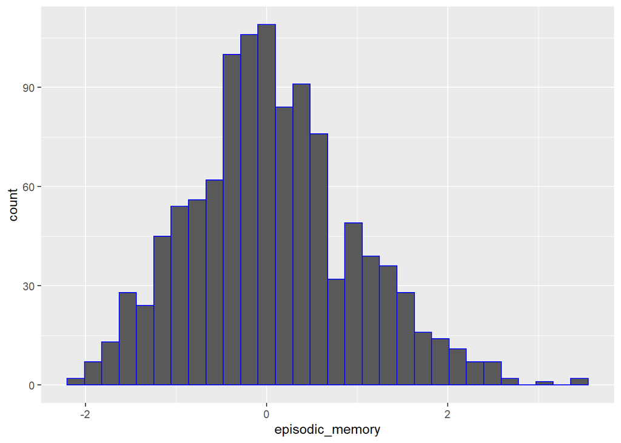

```r
episodic_memory_distribution
```

The histogram indicates the distribution of episodic memory z scores is right skewed. Normality was tested via the shapiro-wilk test, and at the 0.05 significance level, we conclude the distribution of scores is NOT normal.

```r
midus %>%
  summarize(
    mean_episodic = mean(episodic_memory),
    median_episodic=median(episodic_memory),
    sd = sd(episodic_memory),
    min = min(episodic_memory),
    max = max(episodic_memory)
  ) %>%
  knitr::kable()
```

| mean_episodic | median_episodic | sd | min | max |
| --- | --- | --- | --- | --- |
| 0.0679781 | 0.0128389 | 0.9150803 | -2.155253 | 3.405208 |

The table above provides univariate statistics on episodic memory z scores.

Let’s now take a look at executive functioning.

```r
exec_functioning_distribution <- ggplot(midus,aes(x=executive_func)) + geom_histogram(color = "blue")
shapiro.test(midus$executive_func)
```

```
##
##  Shapiro-Wilk normality test
##
## data:  midus$executive_func
## W = 0.99617, p-value = 0.007999
```

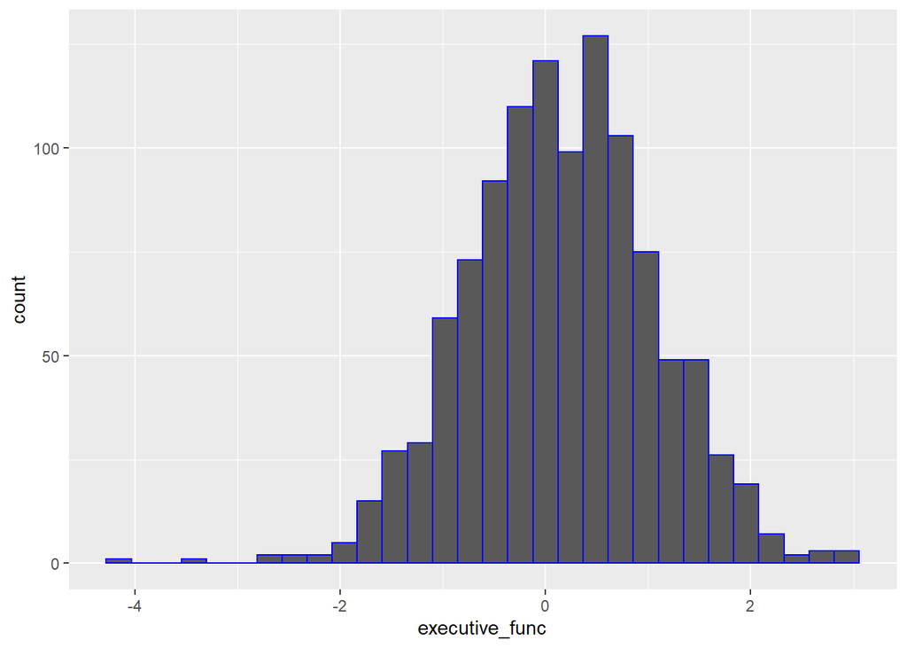

```r
exec_functioning_distribution
```

The histogram indicates slight skewness, but mainly the existence of possible outliers. The shapiro wilks test also indicates non-normality, but I suspect this is due to outliers.

```r
midus %>%
  summarize(
    mean_exec = mean(executive_func),
    median_exec=median(executive_func),
    sd = sd(executive_func),
    min = min(executive_func),
    max = max(executive_func)
  ) %>%
  knitr::kable()
```

| mean_exec | median_exec | sd | min | max |
| --- | --- | --- | --- | --- |
| 0.1539497 | 0.1634781 | 0.9078578 | -4.184306 | 2.905415 |

The table above provides univariate statistics on executive function z-scores.

## Childhood Trauma

Childhood Trauma is broken down into 6 components scores. These components are emotional abuse,emotional neglect, minimization/denial,physical abuse, physical neglect, and sexual abuse. For this study, we will be categorizing trauma into two strata, Threat and Deprivation. Threat is the sum of the scores for emotional abuse, physical abuse and sexual abuse. While deprivation is the sum of emotional neglect, minimization/denial, and parental neglect. As you can see the division of the two strata make sense as one threat in the purview of childhood trauma refers to abuse, while deprivation refers to neglect. Now lets dive into each category.

```r
midus %>%
  summarize(
    mean_threat = mean(threat),
    median_threat=median(threat),
    sd = sd(threat),
    min = min(threat),
    max = max(threat)
  ) %>%
  knitr::kable()
```

| mean_threat | median_threat | sd | min | max |
| --- | --- | --- | --- | --- |
| 21.50309 | 18 | 9.067415 | 15 | 75 |

The table above provides univariate statistics for childhood threat scores.

```r
midus %>%
  summarize(
    mean_deprivation = mean(deprivation),
    median_deprivaton=median(deprivation),
    sd = sd(deprivation),
    min = min(deprivation),
    max = max(deprivation)
  )
```

```
##   mean_deprivation median_deprivaton       sd min max
## 1         17.10527                15 6.279626  10  43
```

The table above provides univariate statistics regarding deprivation scores.

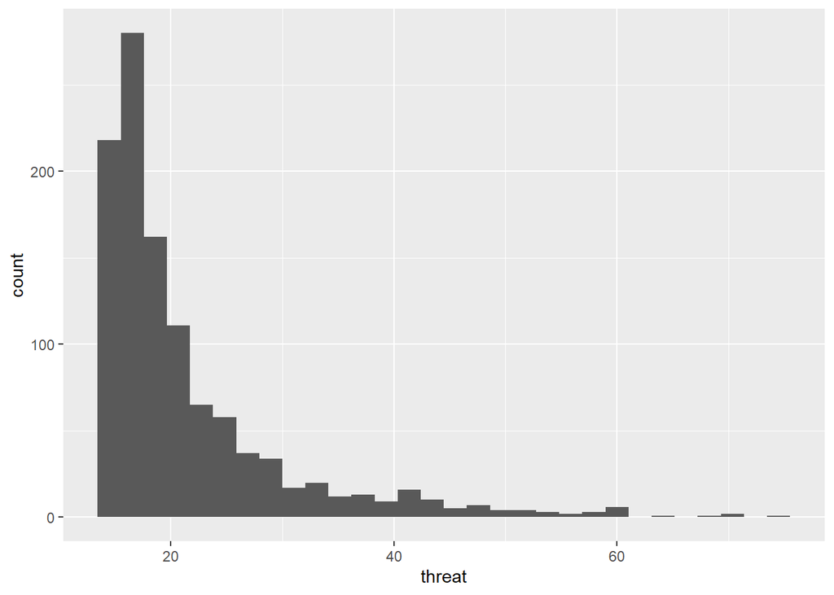

```r
ggplot(midus,aes(x=threat)) +geom_histogram()
```

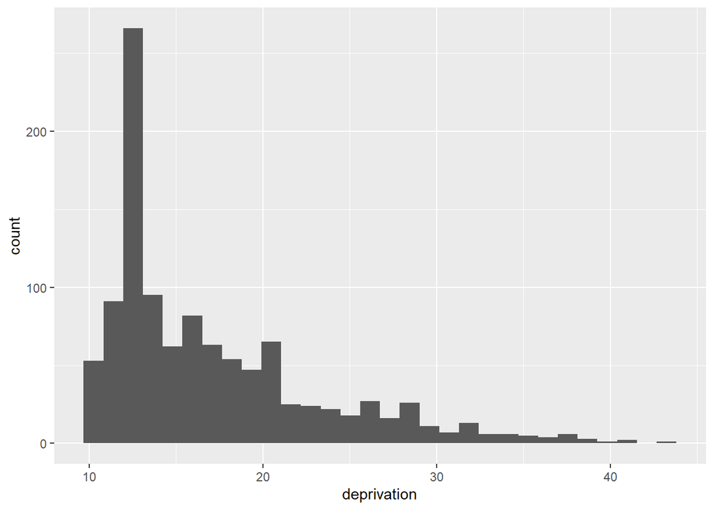

```r
ggplot(midus,aes(x=deprivation)) +geom_histogram()
```

## Unadjusted Analysis

Now that we have looked at both cognition and childhood trauma individually as variables, lets explore the relationship between these two variables.

### Composite Cognition

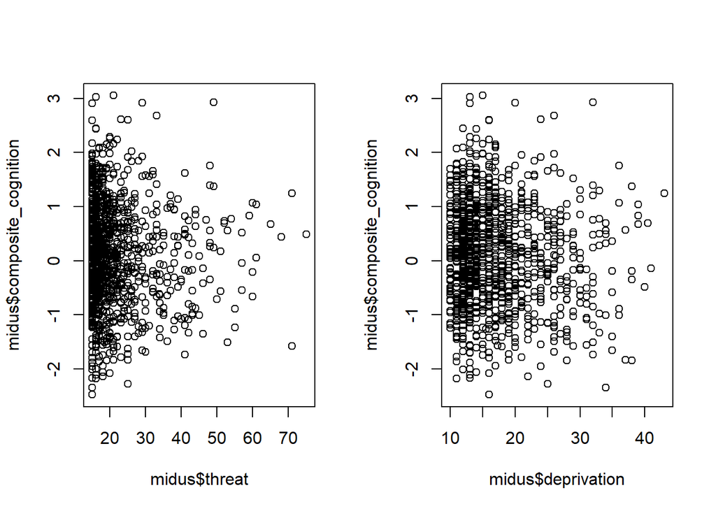

```r
par(mfrow=c(1,2))
plot(midus$threat,midus$composite_cognition)
plot(midus$deprivation,midus$composite_cognition)
```

```r
fit1 <- lmer(composite_cognition ~ threat + deprivation + (1|family_id), data=midus)

summary(fit1)
```

```
## Linear mixed model fit by REML ['lmerMod']
## Formula: composite_cognition ~ threat + deprivation + (1 | family_id)
##    Data: midus
##
## REML criterion at convergence: 2550.7
##
## Scaled residuals:
##      Min       1Q   Median       3Q      Max
## -1.97770 -0.48149 -0.01154  0.46162  2.31229
##
## Random effects:
##  Groups    Name        Variance Std.Dev.
##  family_id (Intercept) 0.4383   0.6621
##  Residual              0.3761   0.6133
## Number of obs: 979, groups:  family_id, 844
##
## Fixed effects:
##              Estimate Std. Error t value
## (Intercept)  0.290394   0.090226   3.219
## threat       0.004134   0.004619   0.895
## deprivation -0.011905   0.006359  -1.872
##
## Correlation of Fixed Effects:
##             (Intr) threat
## threat      -0.292
## deprivation -0.476 -0.664
```

### Episodic Memory

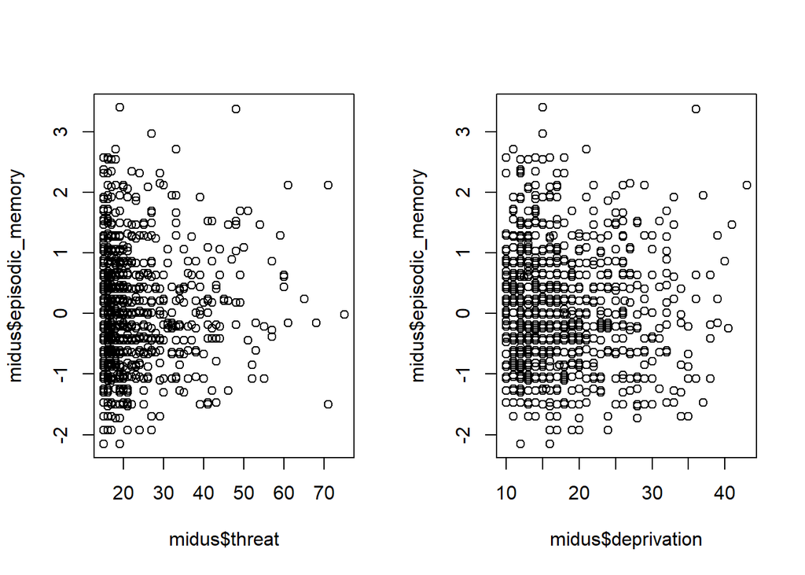

```r
par(mfrow=c(1,2))
plot(midus$threat,midus$episodic_memory)
plot(midus$deprivation,midus$episodic_memory)
```

```r
fit2 <- lmer(episodic_memory ~ threat + +deprivation + (1|family_id), data=midus)

summary(fit2)
```

```
## Linear mixed model fit by REML ['lmerMod']
## Formula: episodic_memory ~ threat + +deprivation + (1 | family_id)
##    Data: midus
##
## REML criterion at convergence: 2585.6
##
## Scaled residuals:
##     Min      1Q  Median      3Q     Max
## -2.2860 -0.5780 -0.0774  0.5541  3.4103
##
## Random effects:
##  Groups    Name        Variance Std.Dev.
##  family_id (Intercept) 0.2263   0.4757
##  Residual              0.5877   0.7666
## Number of obs: 979, groups:  family_id, 844
##
## Fixed effects:
##              Estimate Std. Error t value
## (Intercept)  0.073687   0.090306   0.816
## threat       0.006174   0.004670   1.322
## deprivation -0.006671   0.006483  -1.029
##
## Correlation of Fixed Effects:
##             (Intr) threat
## threat      -0.278
## deprivation -0.482 -0.671
```

### Executive Functioning

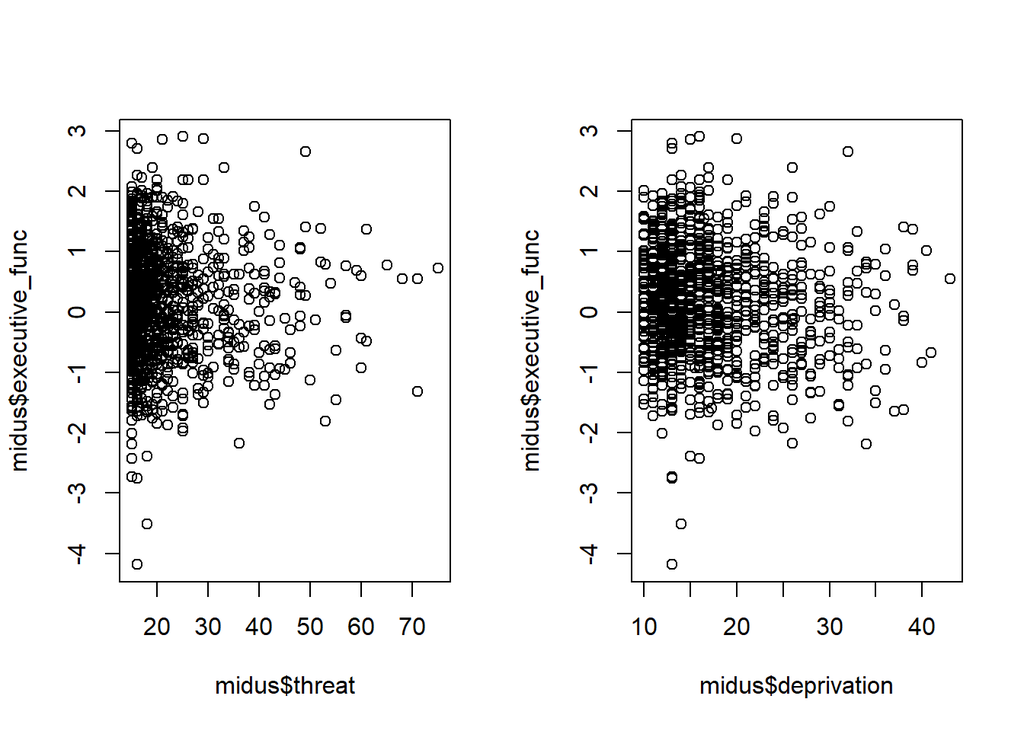

```r
par(mfrow=c(1,2))
plot(midus$threat,midus$executive_func)
plot(midus$deprivation,midus$executive_func)
```

```r
fit3 <- lmer(executive_func ~ threat + +deprivation + (1|family_id), data=midus)

summary(fit3)
```

```
## Linear mixed model fit by REML ['lmerMod']
## Formula: executive_func ~ threat + +deprivation + (1 | family_id)
##    Data: midus
##
## REML criterion at convergence: 2454.9
##
## Scaled residuals:
##     Min      1Q  Median      3Q     Max
## -3.2594 -0.4471  0.0001  0.4322  2.4856
##
## Random effects:
##  Groups    Name        Variance Std.Dev.
##  family_id (Intercept) 0.4458   0.6677
##  Residual              0.3025   0.5500
## Number of obs: 979, groups:  family_id, 844
##
## Fixed effects:
##              Estimate Std. Error t value
## (Intercept)  0.345884   0.086155   4.015
## threat       0.005031   0.004397   1.144
## deprivation -0.013564   0.006034  -2.248
##
## Correlation of Fixed Effects:
##             (Intr) threat
## threat      -0.296
## deprivation -0.474 -0.661
```

# Evaluating Confounding

Now we will be getting into the meat of our analysis. First it should noted that the observations are in fact non-independent. Why is this the case? Well observations were not randomly sampled. We see sampling of participants from the same family, hence the inclusion of family ID in our data set. Cluster sampling was utilized. Therefore participants from the same family likely have similar levels of childhood trauma experience and similar cognition. Now given this, much of the analysis we could question the validity of the analysis run prior, but the purpose of the analysis before is to get an initial look at the data we are working with. the linear models fitted were merely to detect if there is any un-adjusted association.

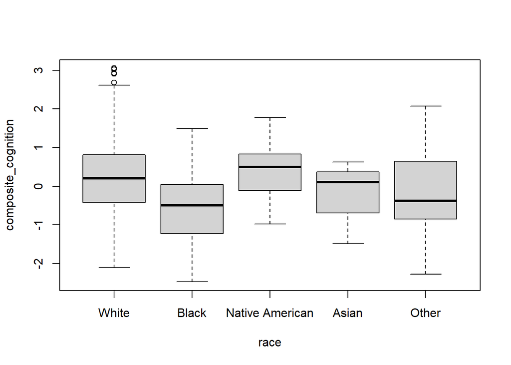

```r
boxplot(composite_cognition ~ race, data=midus)
```

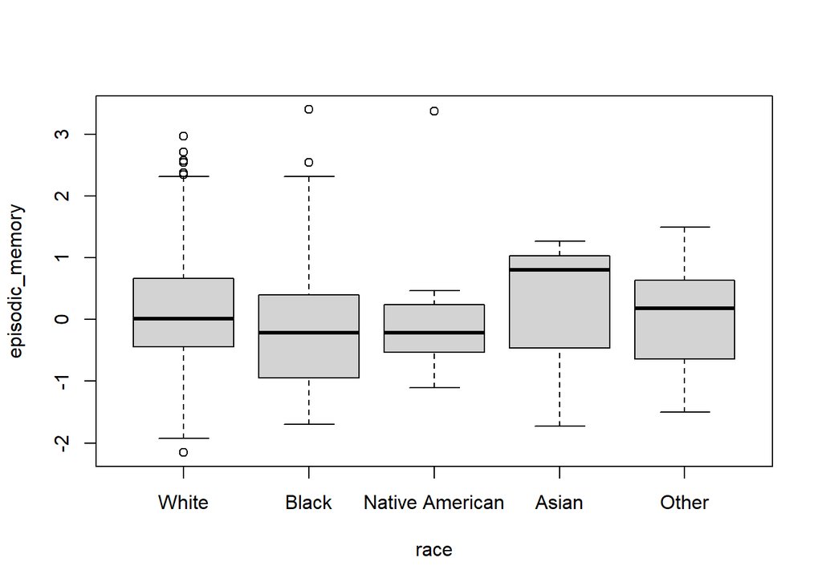

```r
boxplot(episodic_memory ~ race, data=midus)
```

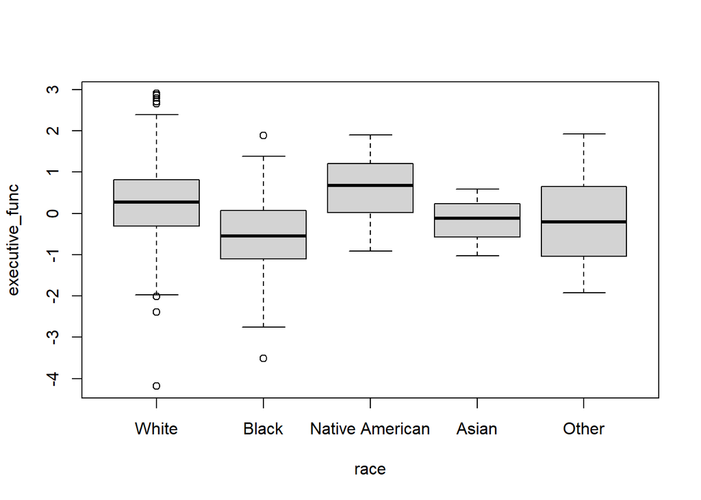

```r
boxplot(executive_func ~ race, data=midus)
```

```r
race_lme <- lmer(composite_cognition~ race + (1|family_id), data=midus)
summary(race_lme)
```

```
## Linear mixed model fit by REML ['lmerMod']
## Formula: composite_cognition ~ race + (1 | family_id)
##    Data: midus
##
## REML criterion at convergence: 2519.1
##
## Scaled residuals:
##      Min       1Q   Median       3Q      Max
## -1.92707 -0.49788 -0.01158  0.46608  2.26216
##
## Random effects:
##  Groups    Name        Variance Std.Dev.
##  family_id (Intercept) 0.4342   0.6589
##  Residual              0.3681   0.6067
## Number of obs: 979, groups:  family_id, 844
##
## Fixed effects:
##                     Estimate Std. Error t value
## (Intercept)          0.20166    0.03121   6.461
## raceBlack           -0.65717    0.18329  -3.585
## raceNative American  0.40882    0.25123   1.627
## raceAsian           -0.45386    0.51808  -0.876
## raceOther           -0.41553    0.18378  -2.261
##
## Correlation of Fixed Effects:
##             (Intr) rcBlck rcNtvA racAsn
## raceBlack   -0.170
## racNtvAmrcn -0.107  0.018
## raceAsian   -0.060  0.010  0.006
## raceOther   -0.164  0.028  0.018  0.010
```

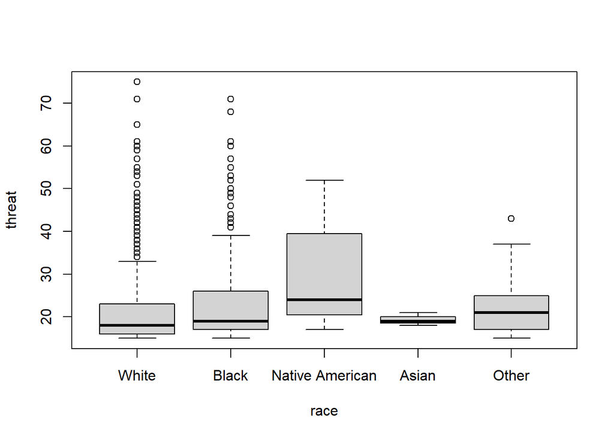

```r
boxplot(threat ~ race, data=midus)
```

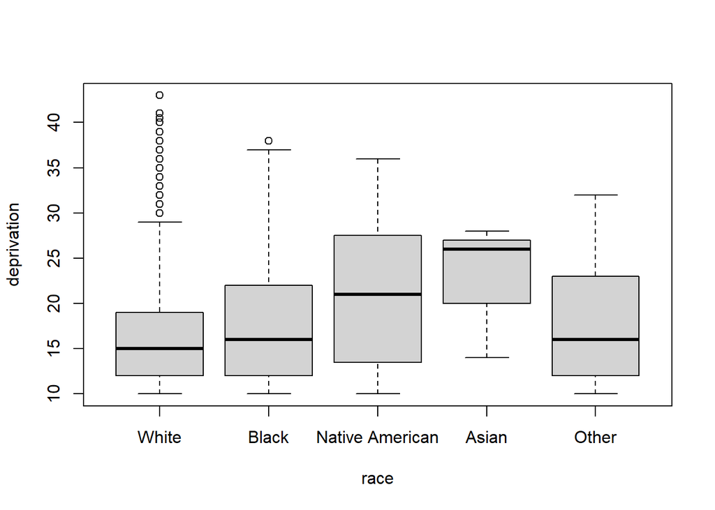

```r
boxplot(deprivation ~ race, data=midus)
```

The box plots indicate that median deprivation and threat scores are different across races.

Thus based on our results we conclude that race is a confounding factor to the association between childhood trauma and cognition.

### Sex

```r
t1 <-
midus %>%
  group_by(sex) %>%
  summarize(
    mean_composite=mean(composite_cognition))

t2 <-
midus %>%
  group_by(sex) %>%
  summarize(
    mean_episodic=mean(episodic_memory))

t3 <-
midus %>%
  group_by(sex) %>%
  summarize(
    mean_exec=mean(executive_func))


knitr::kable(list(t1,t2,t3))
```

| sex | mean_composite |
| --- | --- |
| Male | 0.0911089 |
| Female | 0.1217412 |

| sex | mean_episodic |
| --- | --- |
| Male | -0.2322856 |
| Female | 0.3017861 |

| sex | mean_exec |
| --- | --- |
| Male | 0.2422354 |
| Female | 0.0852037 |

```r
c1 <-
midus %>%
  na.omit() %>%
  group_by(sex) %>%
  summarize(
    mean_deprivation=mean(deprivation))

c2 <-
midus %>%
  na.omit() %>%
  group_by(sex) %>%
  summarize(
    mean_threat=mean(threat))


summary(lmer(deprivation ~ sex + (1|family_id), data=midus))
```

```
## Linear mixed model fit by REML ['lmerMod']
## Formula: deprivation ~ sex + (1 | family_id)
##    Data: midus
##
## REML criterion at convergence: 6261.2
##
## Scaled residuals:
##     Min      1Q  Median      3Q     Max
## -2.0087 -0.5055 -0.1966  0.3525  2.8383
##
## Random effects:
##  Groups    Name        Variance Std.Dev.
##  family_id (Intercept) 20.48    4.526
##  Residual              16.46    4.057
## Number of obs: 979, groups:  family_id, 844
##
## Fixed effects:
##             Estimate Std. Error t value
## (Intercept)  16.7903     0.2951   56.89
## sexFemale     0.3649     0.3922    0.93
##
## Correlation of Fixed Effects:
##           (Intr)
## sexFemale -0.721
```

```r
summary(lmer(threat ~ sex + (1|family_id), data=midus))
```

```
## Linear mixed model fit by REML ['lmerMod']
## Formula: threat ~ sex + (1 | family_id)
##    Data: midus
##
## REML criterion at convergence: 6856.2
##
## Scaled residuals:
##     Min      1Q  Median      3Q     Max
## -2.5001 -0.3243 -0.1942  0.1409  3.5728
##
## Random effects:
##  Groups    Name        Variance Std.Dev.
##  family_id (Intercept) 49.61    7.043
##  Residual              21.26    4.611
## Number of obs: 979, groups:  family_id, 844
##
## Fixed effects:
##             Estimate Std. Error t value
## (Intercept)  19.9845     0.4053  49.305
## sexFemale     2.3100     0.5307   4.353
##
## Correlation of Fixed Effects:
##           (Intr)
## sexFemale -0.709
```

```r
knitr::kable(list(c1,c2))
```

| sex | mean_deprivation |
| --- | --- |
| Male | 16.60928 |
| Female | 17.24202 |

| sex | mean_threat |
| --- | --- |
| Male | 19.74231 |
| Female | 22.37262 |

Though there is not a significant difference in mean deprivation score across genders, but there is a significant difference in mean threat scores across gender.

We conclude sex to be a confounder of the relationship between childhood trauma and cognition.

### Education

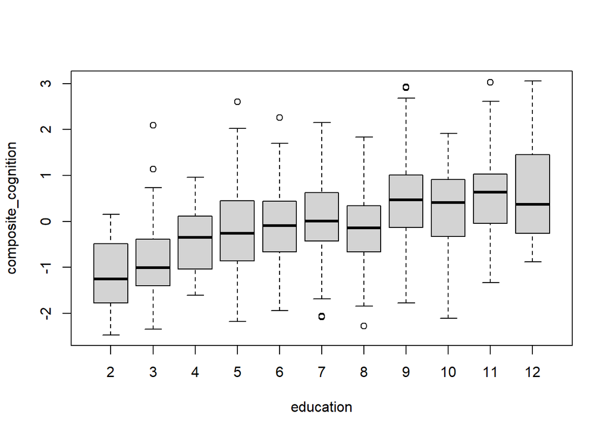

```r
boxplot(composite_cognition ~ education, data=midus)
```

```r
education_lm <- lmer(composite_cognition ~ education + (1|family_id), data=midus)
summary(education_lm)
```

```
## Linear mixed model fit by REML ['lmerMod']
## Formula: composite_cognition ~ education + (1 | family_id)
##    Data: midus
##
## REML criterion at convergence: 2405.6
##
## Scaled residuals:
##      Min       1Q   Median       3Q      Max
## -2.15087 -0.51279 -0.02273  0.46110  2.26212
##
## Random effects:
##  Groups    Name        Variance Std.Dev.
##  family_id (Intercept) 0.3595   0.5996
##  Residual              0.3463   0.5884
## Number of obs: 976, groups:  family_id, 842
##
## Fixed effects:
##             Estimate Std. Error t value
## (Intercept)  -1.0916     0.3335  -3.273
## education3    0.4663     0.3693   1.263
## education4    0.7092     0.4431   1.600
## education5    0.9842     0.3387   2.906
## education6    1.0302     0.3399   3.031
## education7    1.1971     0.3572   3.351
## education8    1.0894     0.3458   3.150
## education9    1.5728     0.3381   4.651
## education10   1.3470     0.3542   3.803
## education11   1.6696     0.3390   4.924
## education12   1.7157     0.3559   4.820
##
## Correlation of Fixed Effects:
##             (Intr) edctn3 edctn4 edctn5 edctn6 edctn7 edctn8 edctn9 edct10
## education3  -0.903
## education4  -0.752  0.680
## education5  -0.984  0.890  0.743
## education6  -0.981  0.886  0.739  0.967
## education7  -0.934  0.846  0.703  0.920  0.916
## education8  -0.964  0.871  0.738  0.951  0.948  0.902
## education9  -0.986  0.891  0.742  0.971  0.967  0.921  0.951
## education10 -0.941  0.850  0.708  0.927  0.925  0.879  0.908  0.930
## education11 -0.979  0.884  0.737  0.964  0.961  0.914  0.944  0.967  0.923
## education12 -0.937  0.846  0.705  0.922  0.919  0.876  0.903  0.924  0.883
##             edct11
## education3
## education4
## education5
## education6
## education7
## education8
## education9
## education10
## education11
## education12  0.919
```

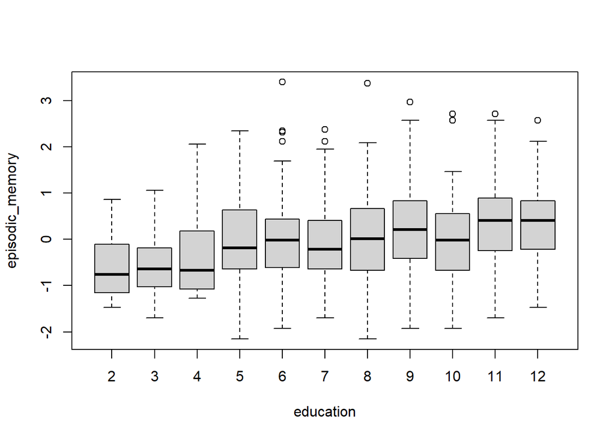

```r
boxplot(episodic_memory ~ education, data=midus)
```

```r
education_lm2 <- lmer(episodic_memory ~ education + (1|family_id), data=midus)
summary(education_lm2)
```

```
## Linear mixed model fit by REML ['lmerMod']
## Formula: episodic_memory ~ education + (1 | family_id)
##    Data: midus
##
## REML criterion at convergence: 2535.6
##
## Scaled residuals:
##     Min      1Q  Median      3Q     Max
## -2.1725 -0.5787 -0.0425  0.5561  3.3751
##
## Random effects:
##  Groups    Name        Variance Std.Dev.
##  family_id (Intercept) 0.2576   0.5075
##  Residual              0.5295   0.7276
## Number of obs: 976, groups:  family_id, 842
##
## Fixed effects:
##             Estimate Std. Error t value
## (Intercept) -0.41759    0.35864  -1.164
## education3  -0.14920    0.39655  -0.376
## education4   0.05993    0.48375   0.124
## education5   0.36704    0.36418   1.008
## education6   0.42835    0.36552   1.172
## education7   0.38140    0.38405   0.993
## education8   0.46597    0.37207   1.252
## education9   0.65498    0.36360   1.801
## education10  0.41800    0.38117   1.097
## education11  0.77475    0.36536   2.121
## education12  0.70330    0.38276   1.837
##
## Correlation of Fixed Effects:
##             (Intr) edctn3 edctn4 edctn5 edctn6 edctn7 edctn8 edctn9 edct10
## education3  -0.904
## education4  -0.741  0.671
## education5  -0.985  0.891  0.732
## education6  -0.981  0.887  0.728  0.967
## education7  -0.934  0.846  0.692  0.920  0.916
## education8  -0.964  0.872  0.722  0.950  0.947  0.901
## education9  -0.986  0.892  0.731  0.972  0.968  0.921  0.951
## education10 -0.941  0.851  0.698  0.927  0.924  0.879  0.907  0.929
## education11 -0.979  0.885  0.726  0.964  0.961  0.914  0.944  0.967  0.922
## education12 -0.937  0.847  0.695  0.923  0.919  0.876  0.903  0.925  0.882
##             edct11
## education3
## education4
## education5
## education6
## education7
## education8
## education9
## education10
## education11
## education12  0.919
```

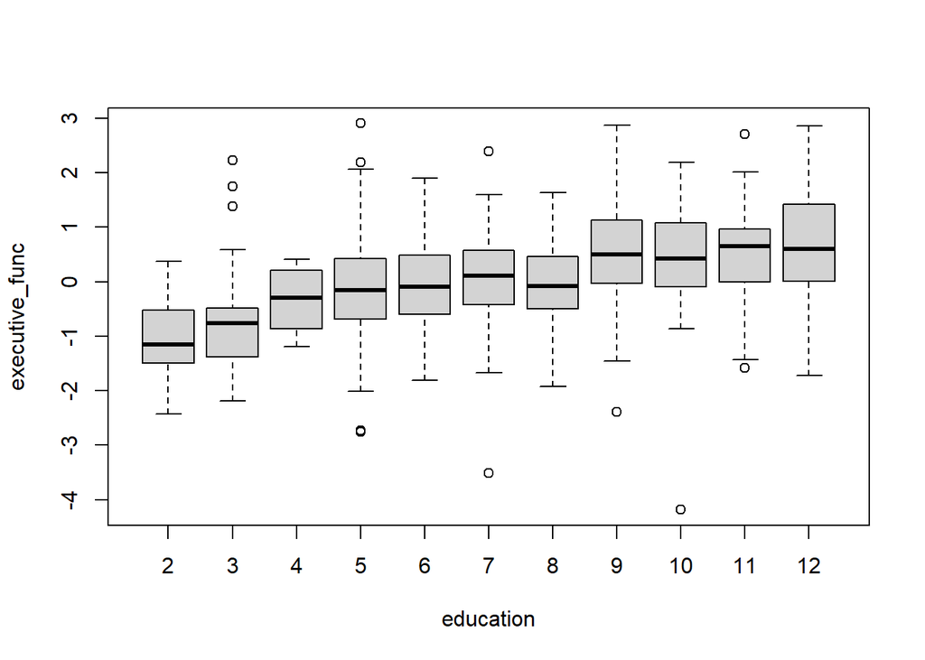

```r
boxplot(executive_func ~ education, data=midus)
```

```r
education_lm3 <- lmer(executive_func ~ education + (1|family_id), data=midus)
summary(education_lm3)
```

```
## Linear mixed model fit by REML ['lmerMod']
## Formula: executive_func ~ education + (1 | family_id)
##    Data: midus
##
## REML criterion at convergence: 2324.4
##
## Scaled residuals:
##     Min      1Q  Median      3Q     Max
## -3.6588 -0.4646 -0.0319  0.4353  2.3919
##
## Random effects:
##  Groups    Name        Variance Std.Dev.
##  family_id (Intercept) 0.3698   0.6081
##  Residual              0.2863   0.5351
## Number of obs: 976, groups:  family_id, 842
##
## Fixed effects:
##             Estimate Std. Error t value
## (Intercept)  -0.9334     0.3187  -2.929
## education3    0.4474     0.3531   1.267
## education4    0.5606     0.4208   1.332
## education5    0.9057     0.3237   2.798
## education6    0.9029     0.3249   2.779
## education7    1.1409     0.3414   3.342
## education8    0.9850     0.3304   2.981
## education9    1.4555     0.3231   4.504
## education10   1.2357     0.3384   3.652
## education11   1.4961     0.3237   4.621
## education12   1.5829     0.3401   4.654
##
## Correlation of Fixed Effects:
##             (Intr) edctn3 edctn4 edctn5 edctn6 edctn7 edctn8 edctn9 edct10
## education3  -0.903
## education4  -0.757  0.684
## education5  -0.984  0.890  0.748
## education6  -0.981  0.885  0.743  0.967
## education7  -0.933  0.846  0.707  0.919  0.916
## education8  -0.965  0.871  0.744  0.952  0.949  0.903
## education9  -0.986  0.891  0.747  0.971  0.967  0.921  0.951
## education10 -0.942  0.850  0.713  0.927  0.925  0.879  0.908  0.930
## education11 -0.979  0.884  0.741  0.964  0.961  0.914  0.944  0.967  0.923
## education12 -0.937  0.845  0.709  0.922  0.919  0.877  0.903  0.924  0.884
##             edct11
## education3
## education4
## education5
## education6
## education7
## education8
## education9
## education10
## education11
## education12  0.920
```

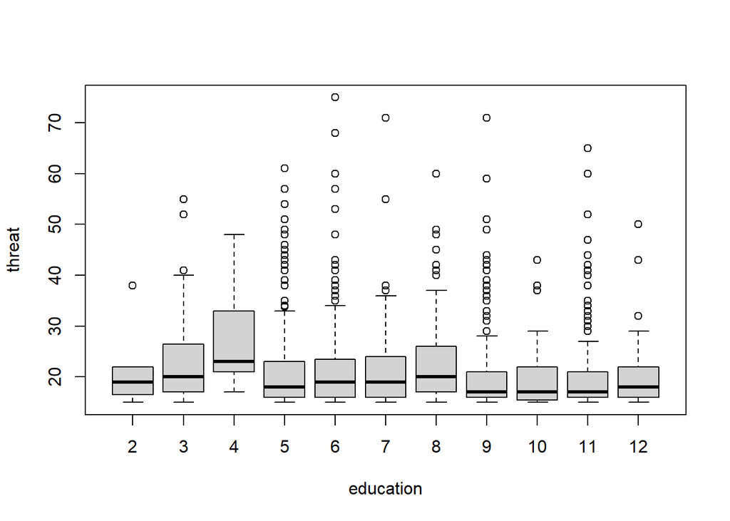

```r
boxplot(threat ~ education, data=midus)
```

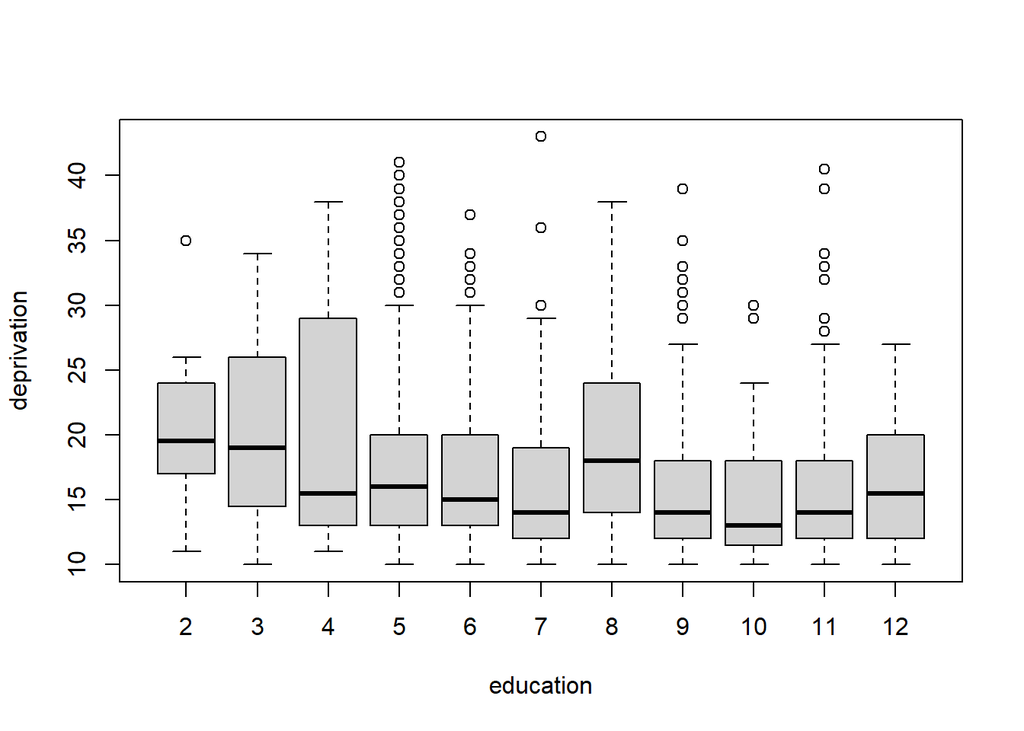

```r
boxplot(deprivation ~ education, data=midus)
```